# Exercise Sheet 2

This exercise sheet is an [R Markdown](https://rmarkdown.rstudio.com/) file. To generate an HTML file from it, use the **Knit** button in RStudio.

The *European Soccer Database* contains data on more than 25.000 national football matches from the best European leagues. The aim of this exercise is to present interesting relationships in R using exploratory data analysis and visualization.

First you need to access some tables in the database. To do so, [download the database](https://1drv.ms/u/s!AlrZt1pKHg25gch_i-b1mAbOtWU44Q?e=AMhg1B) and place it in the same folder as this .Rmd file. You can then use the `RSQLite::dbConnect()` function to connect to the database. To access a particular database table and convert it to a `data.frame`, you can use the `tbl_df(dbGetQuery(connection, 'SELECT * FROM table_xyz'))` command as displayed below.

```r
# Load libraries (they need to be installed on the first run via install.packages)
# You do not need to use these libraries, though
library(RSQLite)
library(stringr)
library(ggplot2)
library(dplyr)
library(tidyr)
library(forcats)
library(lubridate)

# connect to database
con <- dbConnect(SQLite(), dbname = "EuropeanSoccer.sqlite")
# table queries
match <- tibble::as_tibble(dbGetQuery(con, "SELECT * FROM Match"))
league <- tibble::as_tibble(dbGetQuery(con,"SELECT * FROM League"))
```

*Example code for a visualization: Below, you can find a code chunk that contains code to create a basic scatterplot.*

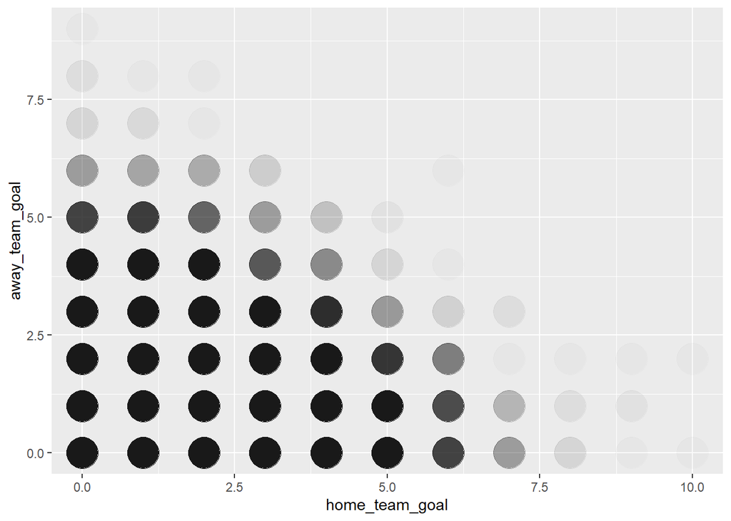

```r
# Example visualization...
match %>%
  ggplot(aes(x = home_team_goal, y = away_team_goal)) +
  geom_point(alpha = 1/50, size = 10)
```

1. The first leagues of Spain, England, Germany and Italy are considered the four most attractive football leagues in Europe. In which of the four leagues were the most or the fewest goals scored per game on average?

```r
# Create total goals column
match$total_goals <- match$home_team_goal + match$away_team_goal

# Merge match and league tables
merged_data <- match %>%
  left_join(league, by = c("league_id" = "id"))

# Filter top four leagues
top_leagues <- merged_data %>%
  filter(name %in% c(
    "Spain LIGA BBVA",
    "England Premier League",
    "Germany 1. Bundesliga",
    "Italy Serie A"
  ))

# Calculate average goals per game
avg_goals <- top_leagues %>%
  group_by(name) %>%
  summarise(avg_goals_per_game = mean(total_goals, na.rm = TRUE))

# Print results
avg_goals
```

```
## # A tibble: 4 × 2
##   name                   avg_goals_per_game
##   <chr>                               <dbl>
## 1 England Premier League               2.71
## 2 Germany 1. Bundesliga                2.90
## 3 Italy Serie A                        2.62
## 4 Spain LIGA BBVA                      2.77
```

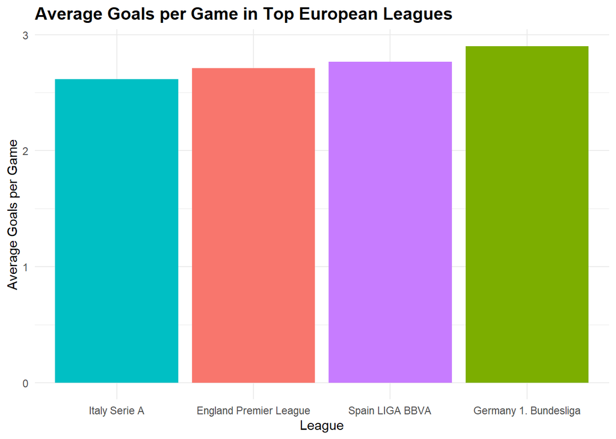

```r
# Bar chart
ggplot(avg_goals,
       aes(x = reorder(name, avg_goals_per_game),
           y = avg_goals_per_game,
           fill = name)) +

  geom_bar(stat = "identity") +

  labs(
    title = "Average Goals per Game in Top European Leagues",
    x = "League",
    y = "Average Goals per Game"
  ) +

  theme_minimal() +

  theme(
    legend.position = "none",
    plot.title = element_text(face = "bold", size = 14)
  )
```

The bar chart compares the average number of goals scored per game across the four major European football leagues. Germany’s Bundesliga had the highest average goals scored per game, while Italy’s Serie A had the lowest average. This indicates that Bundesliga matches were generally more attack-oriented and higher-scoring.

[output not shown]

[output not shown]

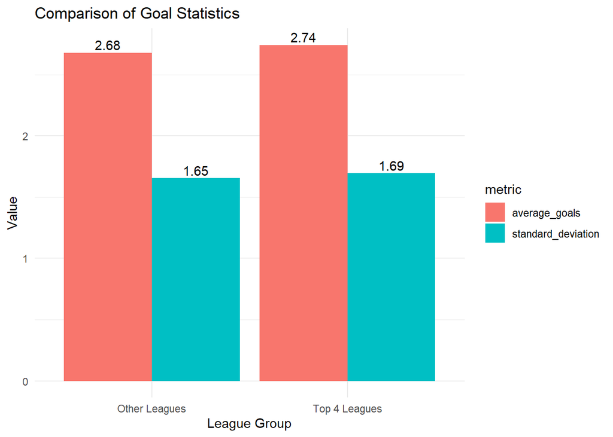

```r
# Convert to long format for plotting
league_stats_long <- league_stats %>%
  pivot_longer(
    cols = c(average_goals, standard_deviation),
    names_to = "metric",
    values_to = "value"
  )

# Create plot
p <- ggplot(league_stats_long,
            aes(x = league_group,
                y = value,
                fill = metric)) +

  geom_bar(stat = "identity",
           position = "dodge") +
  geom_text(aes(label = round(value, 2)),
          position = position_dodge(width = 0.9),
          vjust = -0.3)   +

  labs(
    title = "Comparison of Goal Statistics",
    x = "League Group",
    y = "Value"
  ) +

  theme_minimal()

print(p)
```

The comparison shows differences between the four major European leagues and the remaining leagues in terms of average goals and variability. The standard deviation measures how spread out the goals per match are. Higher standard deviation indicates greater unpredictability in match outcomes.

3. Is there really a home advantage? Use a box plot to show the number of goals scored by home and away teams.

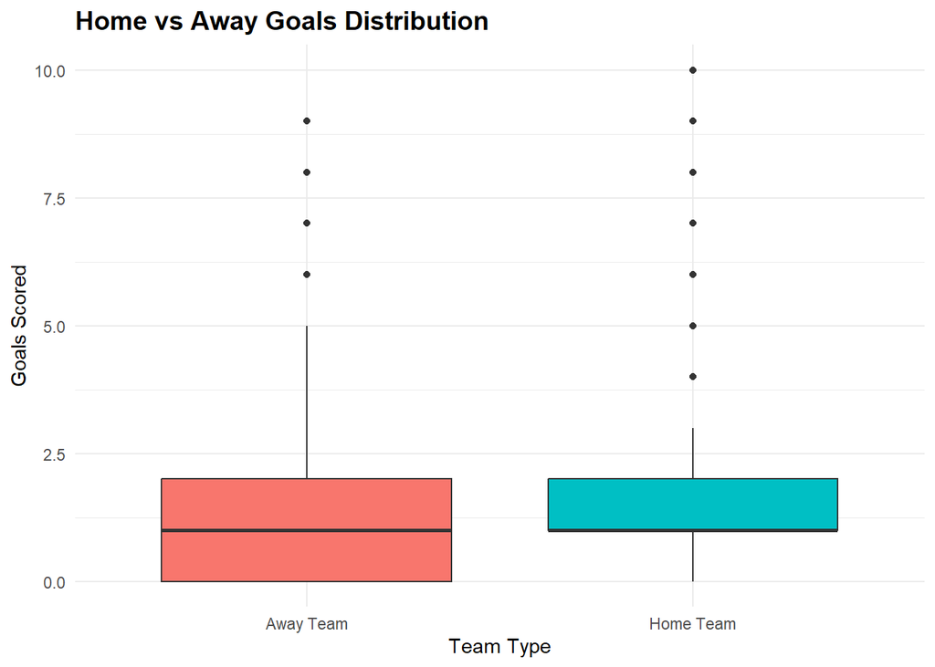

```r
# Create boxplot for home and away goals

boxplot_data <- data.frame(
  goals = c(match$home_team_goal, match$away_team_goal),
  team_type = c(
    rep("Home Team", length(match$home_team_goal)),
    rep("Away Team", length(match$away_team_goal))
  )
)

# Plot
p <- ggplot(boxplot_data,
            aes(x = team_type,
                y = goals,
                fill = team_type)) +

  geom_boxplot() +

  labs(
    title = "Home vs Away Goals Distribution",
    x = "Team Type",
    y = "Goals Scored"
  ) +

  theme_minimal() +

  theme(
    legend.position = "none",
    plot.title = element_text(face = "bold", size = 14)
  )

# Show plot
print(p)
```

4. *“All soccer players are fair-weather players!”* Check the assertion with a line chart: Do on average more goals fall per game in the summer months than in the rest of the year?

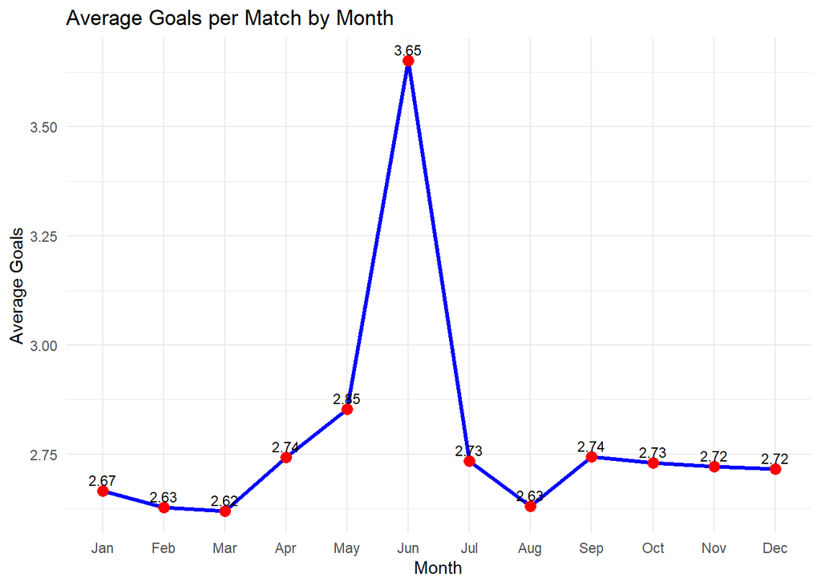

```r
# Convert date column to date format
match$date <- as.Date(match$date)

# Extract month
match$month <- month(match$date, label = TRUE)

# Create total goals column
match$total_goals <- match$home_team_goal + match$away_team_goal

# Calculate average goals per month
monthly_goals <- match %>%
  group_by(month) %>%
  summarise(
    average_goals = mean(total_goals, na.rm = TRUE)
  )

# Create line chart
p <- ggplot(monthly_goals,
            aes(x = month,
                y = average_goals,
                group = 1)) +

  geom_line(color = "blue", linewidth = 1.2) +

  geom_point(size = 3, color = "red") +

  geom_text(aes(label = round(average_goals, 2)),
            vjust = -0.5,
            size = 3) +

  labs(
    title = "Average Goals per Match by Month",
    x = "Month",
    y = "Average Goals"
  ) +

  theme_minimal()

# Show plot
print(p)
```

5. Use an estimated density function curve AND a QQ-Plot to check whether the `home_team_possession` variable is (approximately) normally distributed.

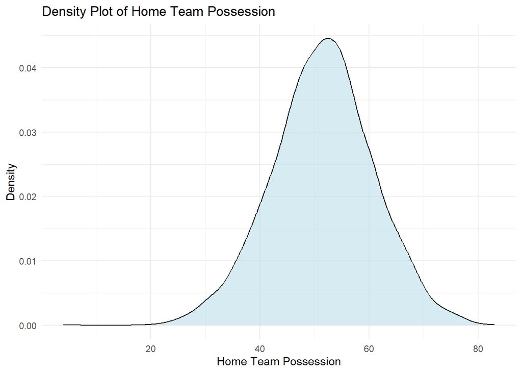

```r
# Create possession variable and remove missing values
possession <- na.omit(match$home_team_possession)

# Density Plot
p1 <- ggplot(data.frame(possession),
             aes(x = possession)) +

  geom_density(fill = "lightblue", alpha = 0.5) +

  labs(
    title = "Density Plot of Home Team Possession",
    x = "Home Team Possession",
    y = "Density"
  ) +

  theme_minimal()

# Show density plot
print(p1)
```

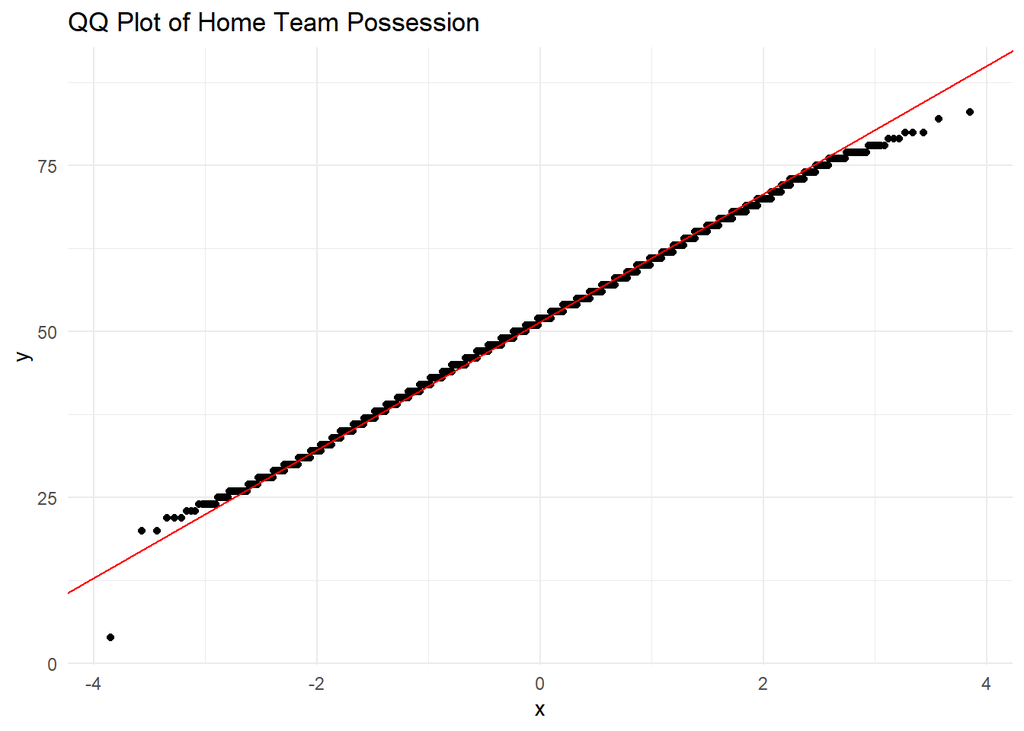

```r
# QQ Plot
p2 <- ggplot(data.frame(possession),
             aes(sample = possession)) +

  stat_qq() +

  stat_qq_line(color = "red") +

  labs(
    title = "QQ Plot of Home Team Possession"
  ) +

  theme_minimal()

# Show QQ plot
print(p2)
```

The density plot and QQ plot are used to visually assess whether the home_team_possession variable follows an approximately normal distribution. The density curve shows the shape of the distribution, while the QQ plot compares the observed data with a theoretical normal distribution. Small deviations from the straight line indicate that the distribution is only approximately normal.

Dataset:

- https://1drv.ms/u/s!AlrZt1pKHg25gch_i-b1mAbOtWU44Q?e=AMhg1B  
  (For database schema and explanation of variables, see: https://www.kaggle.com/hugomathien/soccer)